# Latihan Pertemuan 4/5 ya - Pembangkitan MA(2), AR(2), ARMA(2,2)

Uma Keisha Abriana (M0401241022)

2026-09-23

```r
library(TSA)
```

## Proses MA(2)

Model MA(2) yang akan dibangkitkan adalah

$$Y_t = e_t + \theta_1 e_{t-1} + \theta_2 e_{t-2}$$

dengan $\theta_1 = 0.4$ dan $\theta_2 = 0.6$ sebanyak 300 data.

### Pembangkitan Manual

```r
set.seed(123)
n <- 300
wn <- rnorm(n)

theta1 <- 0.4
theta2 <- 0.6

ma2 <- wn[1:2]
for (i in 3:n) {
  ma2[i] <- wn[i] + theta1 * wn[i - 1] + theta2 * wn[i - 2]
}
```

### Pembangkitan dengan arima.sim

```r
set.seed(123)
ma2.sim <- arima.sim(list(order = c(0, 0, 2), ma = c(theta1, theta2)), n = n)
```

### Plot Time Series

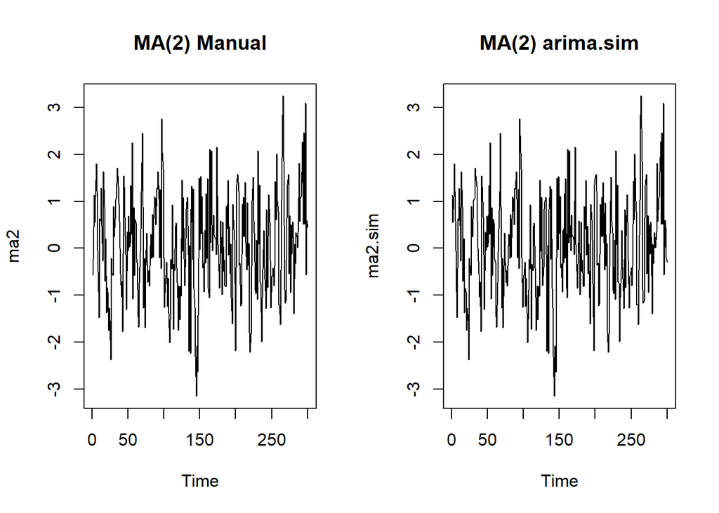

```r
par(mfrow = c(1, 2))
ts.plot(ma2, main = "MA(2) Manual")
ts.plot(ma2.sim, main = "MA(2) arima.sim")
```

```r
par(mfrow = c(1, 1))
```

Plot time series MA(2) manual dan hasil arima.sim terlihat sangat mirip polanya (karena set.seed sama). Nilai data berfluktuasi di sekitar 0, tidak menunjukkan tren naik/turun, dan lebar sebarannya relatif konsisten sepanjang waktu (kira-kira -3 sampai 3). Ini menandakan data stasioner baik dalam rataan maupun ragam.

### Plot ACF

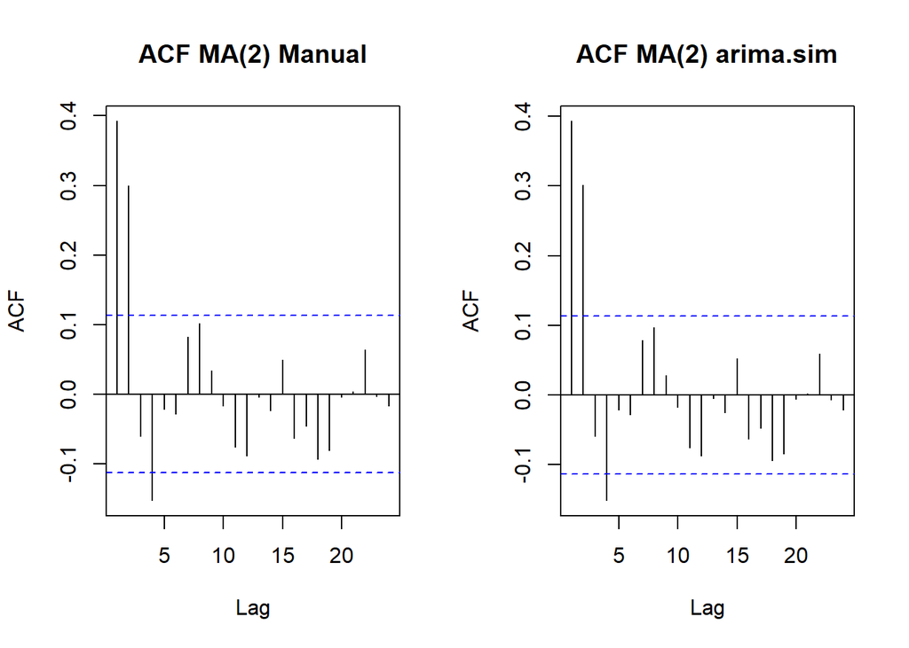

```r
par(mfrow = c(1, 2))
acf(ma2, main = "ACF MA(2) Manual")
acf(ma2.sim, main = "ACF MA(2) arima.sim")
```

```r
par(mfrow = c(1, 1))
```

### Plot PACF

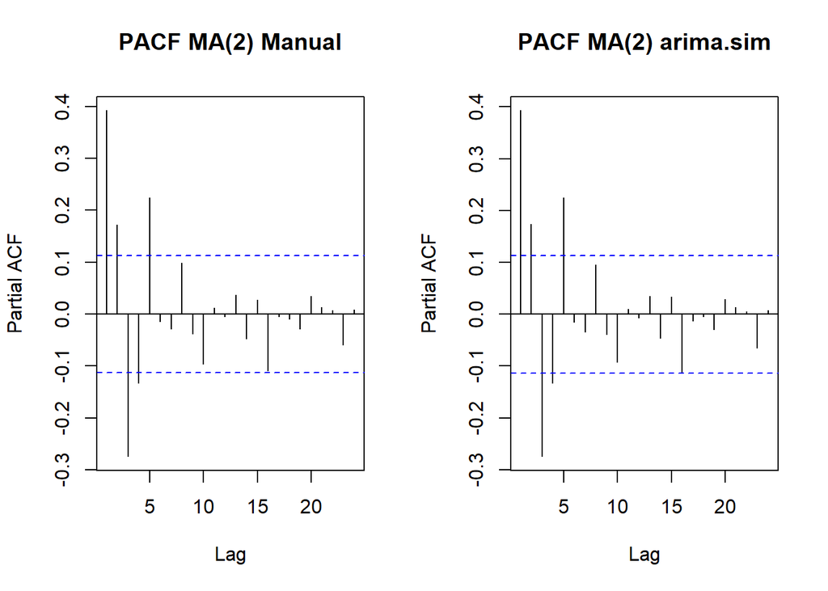

```r
par(mfrow = c(1, 2))
pacf(ma2, main = "PACF MA(2) Manual")
pacf(ma2.sim, main = "PACF MA(2) arima.sim")
```

```r
par(mfrow = c(1, 1))
```

Plot PACF cenderung *tails off* membentuk gelombang sinus, ciri khas proses MA.

### Plot EACF

```r
TSA::eacf(ma2)
```

```
## AR/MA
##   0 1 2 3 4 5 6 7 8 9 10 11 12 13
## 0 x x o x o o o o o o o  o  o  o
## 1 x x x x o o o o o o o  o  o  o
## 2 x x o x o o o o o o o  o  o  o
## 3 x x o o x o o o o o o  o  o  o
## 4 x x x o x o o o o o o  o  o  o
## 5 o x x x x o o o o o o  o  o  o
## 6 x o x x x o o o o o o  o  o  o
## 7 x x o x x o o o o o o  o  o  o
```

```r
TSA::eacf(ma2.sim)
```

```
## AR/MA
##   0 1 2 3 4 5 6 7 8 9 10 11 12 13
## 0 x x o x o o o o o o o  o  o  o
## 1 x x x x o o o o o o o  o  o  o
## 2 x x o x o o o o o o o  o  o  o
## 3 x x o o x o o o o o o  o  o  o
## 4 x x x x x o o o o o o  o  o  o
## 5 o x x x x o o o o o o  o  o  o
## 6 x o x x o o o o o o o  o  o  o
## 7 x x o x x o o o o o o  o  o  o
```

### Scatterplot Antar Lag

```r
# Yt vs Yt-1
yt <- ma2.sim[-1]
yt_1 <- ma2.sim[-n]

# Yt vs Yt-2
yt.2 <- ma2.sim[-c(1, 2)]
yt_2 <- ma2.sim[-c(n - 1, n)]

# Yt vs Yt-3
yt.3 <- ma2.sim[-c(1, 2, 3)]
yt_3 <- ma2.sim[-c(n - 2, n - 1, n)]
```

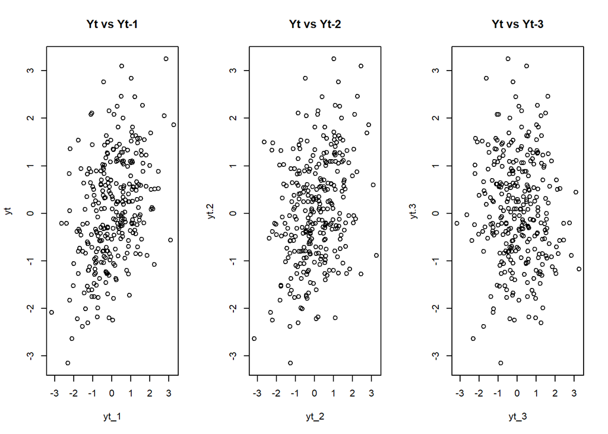

```r
par(mfrow = c(1, 3))
plot(y = yt, x = yt_1, main = "Yt vs Yt-1")
plot(y = yt.2, x = yt_2, main = "Yt vs Yt-2")
plot(y = yt.3, x = yt_3, main = "Yt vs Yt-3")
```

```r
par(mfrow = c(1, 1))
```

Terlihat hubungan positif pada Yt vs Yt-1 dan Yt vs Yt-2, sedangkan Yt vs Yt-3 cenderung tidak menunjukkan pola hubungan (menyebar acak).

### Autokorelasi Empirik vs Teoritis

```r
cor(yt, yt_1)
```

```
## [1] 0.393586
```

```r
cor(yt.2, yt_2)
```

```
## [1] 0.3021451
```

```r
cor(yt.3, yt_3)
```

```
## [1] -0.05893345
```

Secara teoritis, ACF proses MA(2) dirumuskan sebagai:

$$\rho_1=\frac{\theta_1+\theta_1\theta_2}{1+\theta_1^2+\theta_2^2}, \quad
\rho_2=\frac{\theta_2}{1+\theta_1^2+\theta_2^2}, \quad
\rho_k=0 \; \text{untuk } k\geq3$$

```r
denom <- 1 + theta1^2 + theta2^2
rho1.teori <- (theta1 + theta1 * theta2) / denom
rho2.teori <- theta2 / denom
c(rho1.teori = rho1.teori, rho2.teori = rho2.teori, rho3.teori = 0)
```

```
## rho1.teori rho2.teori rho3.teori
##  0.4210526  0.3947368  0.0000000
```

```r
# cek dengan fungsi ARMAacf
ARMAacf(ma = c(theta1, theta2), lag.max = 3)
```

```
##         0         1         2         3
## 1.0000000 0.4210526 0.3947368 0.0000000
```

Nilai korelasi hasil simulasi mendekati nilai teoritis di atas, terutama untuk lag 1 dan 2, sementara korelasi pada lag 3 mendekati nol sesuai teori.

## Proses AR(2)

Model AR(2) yang akan dibangkitkan adalah

$$Y_t = \phi_1 Y_{t-1} + \phi_2 Y_{t-2} + e_t$$

dengan $\phi_1 = 0.5$ dan $\phi_2 = 0.2$ sebanyak 300 data.

### Pembangkitan Manual

```r
set.seed(123)
wn <- rnorm(n)

phi1 <- 0.5
phi2 <- 0.2

ar2 <- wn[1:2]
for (i in 3:n) {
  ar2[i] <- phi1 * ar2[i - 1] + phi2 * ar2[i - 2] + wn[i]
}
```

### Pembangkitan dengan arima.sim

```r
set.seed(123)
ar2.sim <- arima.sim(list(order = c(2, 0, 0), ar = c(phi1, phi2)), n = n)
```

### Plot Time Series

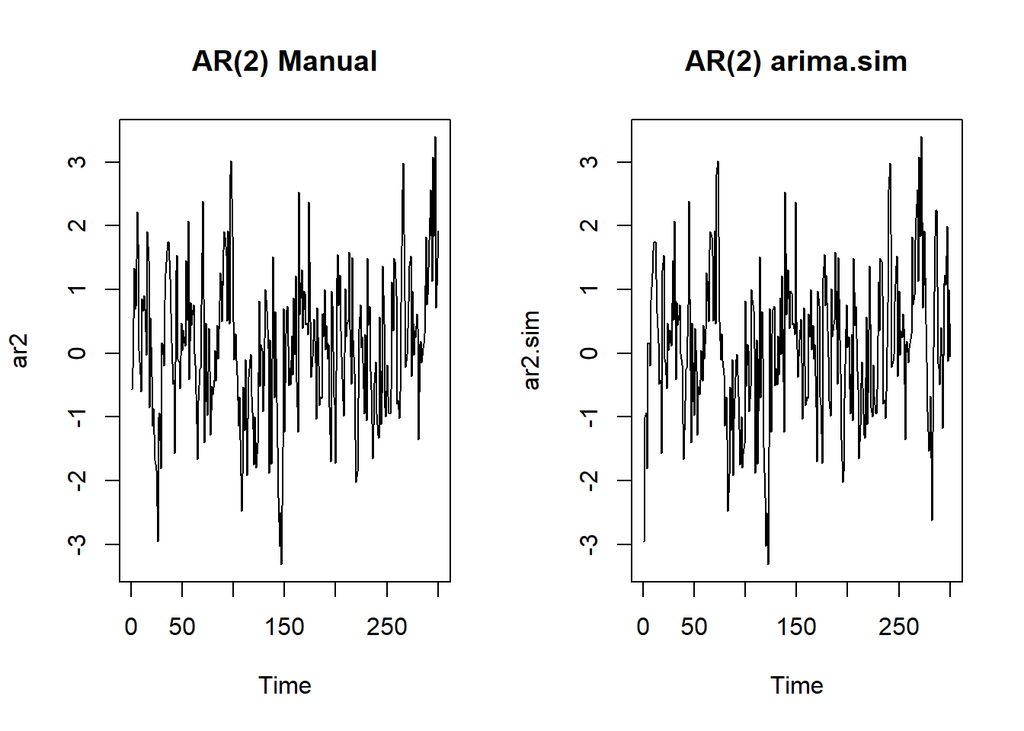

```r
par(mfrow = c(1, 2))
ts.plot(ar2, main = "AR(2) Manual")
ts.plot(ar2.sim, main = "AR(2) arima.sim")
```

```r
par(mfrow = c(1, 1))
```

Data bergerak stabil di sekitar nilai tengah nol tanpa tren, sehingga data dapat dikatakan stasioner. Hal ini juga sesuai dengan syarat kestasioneran AR(2), yaitu $\phi_1+\phi_2<1$, $\phi_2-\phi_1<1$, dan $|\phi_2|<1$, yang seluruhnya terpenuhi oleh $\phi_1=0.5$ dan $\phi_2=0.2$.

### Plot ACF

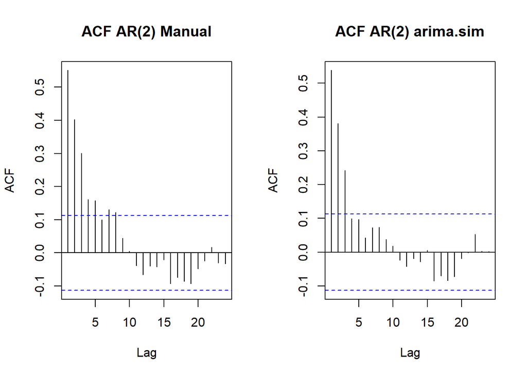

```r
par(mfrow = c(1, 2))
acf(ar2, main = "ACF AR(2) Manual")
acf(ar2.sim, main = "ACF AR(2) arima.sim")
```

```r
par(mfrow = c(1, 1))
```

Plot ACF *tails off* secara eksponensial, ciri khas proses AR.

### Plot PACF

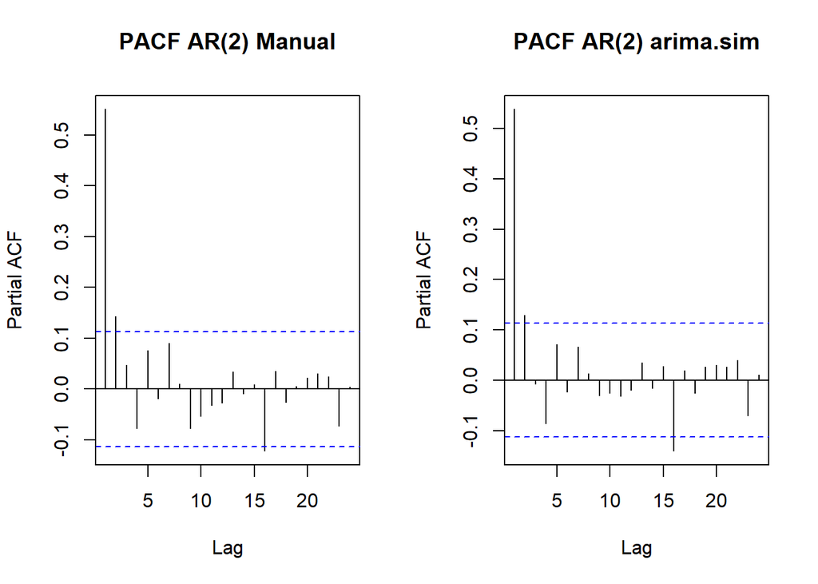

```r
par(mfrow = c(1, 2))
pacf(ar2, main = "PACF AR(2) Manual")
pacf(ar2.sim, main = "PACF AR(2) arima.sim")
```

```r
par(mfrow = c(1, 1))
```

Plot PACF *cuts off* setelah lag ke-2, sesuai dengan ordo AR(2) yang dibangkitkan.

### Plot EACF

```r
TSA::eacf(ar2)
```

```
## AR/MA
##   0 1 2 3 4 5 6 7 8 9 10 11 12 13
## 0 x x x x x o x x o o o  o  o  o
## 1 x o o x o o o o o o o  o  o  o
## 2 x o o o o o o o o o o  o  o  o
## 3 x o o o o o o o o o o  o  o  o
## 4 x o o o o o o o o o o  o  o  o
## 5 x x o o o o o o o o o  o  o  o
## 6 x x o x x o o o o o o  o  o  o
## 7 x x o x x o x o o o o  o  o  o
```

```r
TSA::eacf(ar2.sim)
```

```
## AR/MA
##   0 1 2 3 4 5 6 7 8 9 10 11 12 13
## 0 x x x o o o o o o o o  o  o  o
## 1 x o o x o o o o o o o  o  o  o
## 2 o o o o o o o o o o o  o  o  o
## 3 o x o o o o o o o o o  o  o  o
## 4 x x o o o x o o o o o  o  o  o
## 5 x x o x o o o o o o o  o  o  o
## 6 x x o x x o o o o o o  o  o  o
## 7 x x x x x o o o o o o  o  o  o
```

Segitiga nol pada plot EACF berada pada ordo AR(2) dan MA(0), sesuai dengan model yang dibangkitkan.

### Scatterplot Antar Lag

```r
yt <- ar2.sim[-1]
yt_1 <- ar2.sim[-n]

yt.2 <- ar2.sim[-c(1, 2)]
yt_2 <- ar2.sim[-c(n - 1, n)]

yt.3 <- ar2.sim[-c(1, 2, 3)]
yt_3 <- ar2.sim[-c(n - 2, n - 1, n)]
```

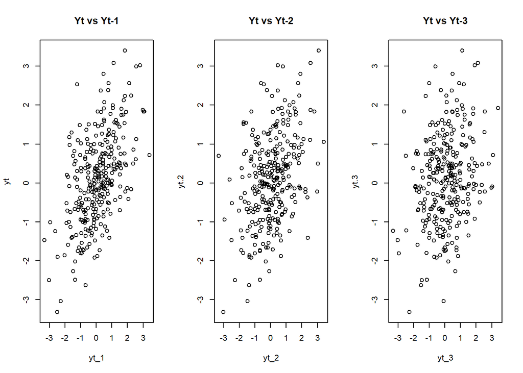

```r
par(mfrow = c(1, 3))
plot(y = yt, x = yt_1, main = "Yt vs Yt-1")
plot(y = yt.2, x = yt_2, main = "Yt vs Yt-2")
plot(y = yt.3, x = yt_3, main = "Yt vs Yt-3")
```

```r
par(mfrow = c(1, 1))
```

Ketiga scatterplot menunjukkan hubungan positif antara Yt dengan lag-lag sebelumnya, meskipun kekuatan hubungan semakin melemah seiring bertambahnya lag, sesuai dengan sifat ACF AR(2) yang *tails off*.

### Autokorelasi Empirik vs Teoritis

```r
cor(yt, yt_1)
```

```
## [1] 0.5448227
```

```r
cor(yt.2, yt_2)
```

```
## [1] 0.3867911
```

```r
cor(yt.3, yt_3)
```

```
## [1] 0.2464424
```

Autokorelasi teoritis AR(2) diperoleh melalui persamaan Yule-Walker:

$$\rho_1=\frac{\phi_1}{1-\phi_2}, \quad
\rho_2=\phi_1\rho_1+\phi_2, \quad
\rho_k=\phi_1\rho_{k-1}+\phi_2\rho_{k-2}\; (k\geq2)$$

```r
rho1.teori <- phi1 / (1 - phi2)
rho2.teori <- phi1 * rho1.teori + phi2
rho3.teori <- phi1 * rho2.teori + phi2 * rho1.teori
c(rho1.teori = rho1.teori, rho2.teori = rho2.teori, rho3.teori = rho3.teori)
```

```
## rho1.teori rho2.teori rho3.teori
##    0.62500    0.51250    0.38125
```

```r
ARMAacf(ar = c(phi1, phi2), lag.max = 3)
```

```
##       0       1       2       3
## 1.00000 0.62500 0.51250 0.38125
```

Nilai korelasi dari data hasil simulasi mendekati nilai teoritis di atas.

## Proses ARMA(2,2)

Model ARMA(2,2) yang akan dibangkitkan adalah

$$Y_t = \phi_1 Y_{t-1} + \phi_2 Y_{t-2} + e_t + \theta_1 e_{t-1} +
\theta_2 e_{t-2}$$

dengan $\phi_1=0.5$, $\phi_2=0.2$, $\theta_1=0.4$, dan $\theta_2=0.6$ sebanyak 300 data.

### Pembangkitan Manual

```r
set.seed(123)
wn <- rnorm(n)

arma22 <- wn[1:2]
for (i in 3:n) {
  arma22[i] <- phi1 * arma22[i - 1] + phi2 * arma22[i - 2] +
    wn[i] + theta1 * wn[i - 1] + theta2 * wn[i - 2]
}
```

### Pembangkitan dengan arima.sim

```r
set.seed(123)
arma22.sim <- arima.sim(
  list(order = c(2, 0, 2), ar = c(phi1, phi2), ma = c(theta1, theta2)),
  n = n
)
```

### Plot Time Series

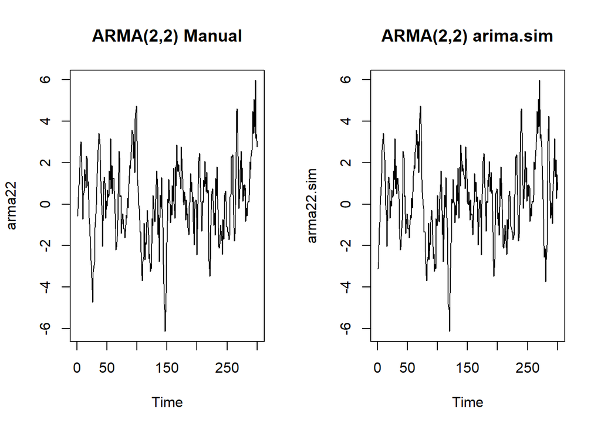

```r
par(mfrow = c(1, 2))
ts.plot(arma22, main = "ARMA(2,2) Manual")
ts.plot(arma22.sim, main = "ARMA(2,2) arima.sim")
```

```r
par(mfrow = c(1, 1))
```

Data bergerak di sekitar nilai tengah nol tanpa tren maupun perubahan lebar pita yang mencolok, sehingga data dapat dikatakan stasioner.

### Plot ACF

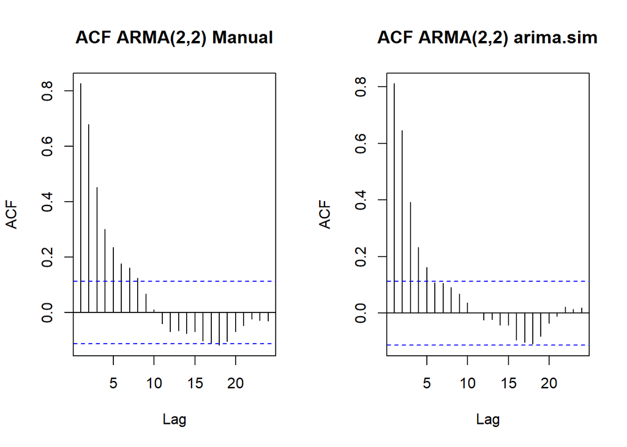

```r
par(mfrow = c(1, 2))
acf(arma22, main = "ACF ARMA(2,2) Manual")
acf(arma22.sim, main = "ACF ARMA(2,2) arima.sim")
```

```r
par(mfrow = c(1, 1))
```

Plot ACF *tails off*, sesuai dengan sifat komponen AR pada model ARMA.

### Plot PACF

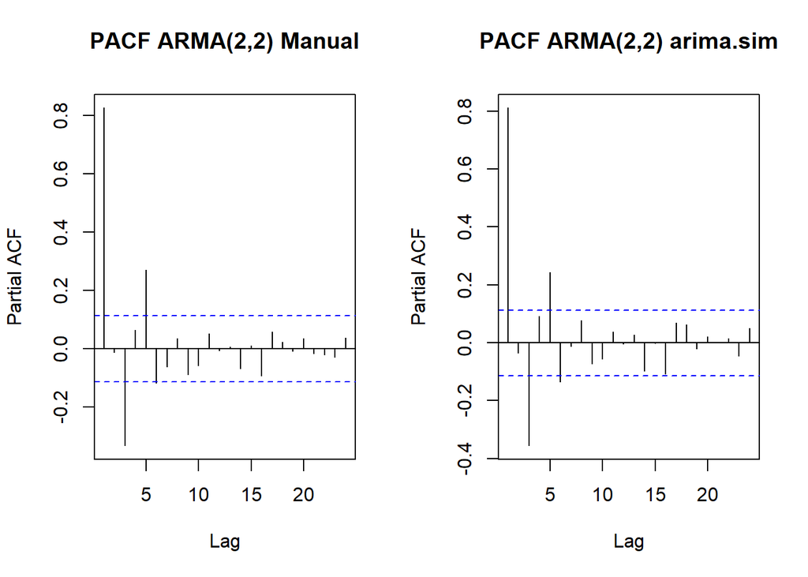

```r
par(mfrow = c(1, 2))
pacf(arma22, main = "PACF ARMA(2,2) Manual")
pacf(arma22.sim, main = "PACF ARMA(2,2) arima.sim")
```

```r
par(mfrow = c(1, 1))
```

Plot PACF juga *tails off*, sesuai dengan sifat komponen MA pada model ARMA. Kombinasi ACF dan PACF yang sama-sama *tails off* menjadi ciri khas proses ARMA campuran.

### Plot EACF

```r
TSA::eacf(arma22)
```

```
## AR/MA
##   0 1 2 3 4 5 6 7 8 9 10 11 12 13
## 0 x x x x x x x x o o o  o  o  o
## 1 o x o x o o o o o o o  o  o  o
## 2 o x o x o o o o o o o  o  o  o
## 3 x x o x o o o x o o o  o  o  o
## 4 x x o x o o o x o o o  o  o  o
## 5 x x o x x o o o o o o  o  o  o
## 6 x x o x o o o o o o o  o  o  o
## 7 x o x x x o o o o o o  o  o  o
```

```r
TSA::eacf(arma22.sim)
```

```
## AR/MA
##   0 1 2 3 4 5 6 7 8 9 10 11 12 13
## 0 x x x x x o o o o o o  o  o  o
## 1 o x o o o x o o o o o  o  o  o
## 2 o x o o o x o o o o o  o  o  o
## 3 x x o x o x o o o o o  o  o  o
## 4 x x o x o x o o o o o  o  o  o
## 5 x x o x x o o o o o o  o  o  o
## 6 x x o x x o o o o o o  o  o  o
## 7 x x x x x o o o o o o  o  o  o
```

Segitiga nol pada plot EACF mengarah pada ordo AR(2) dan MA(2), sesuai dengan model yang dibangkitkan.

### Scatterplot Antar Lag

```r
yt <- arma22.sim[-1]
yt_1 <- arma22.sim[-n]

yt.2 <- arma22.sim[-c(1, 2)]
yt_2 <- arma22.sim[-c(n - 1, n)]

yt.3 <- arma22.sim[-c(1, 2, 3)]
yt_3 <- arma22.sim[-c(n - 2, n - 1, n)]
```

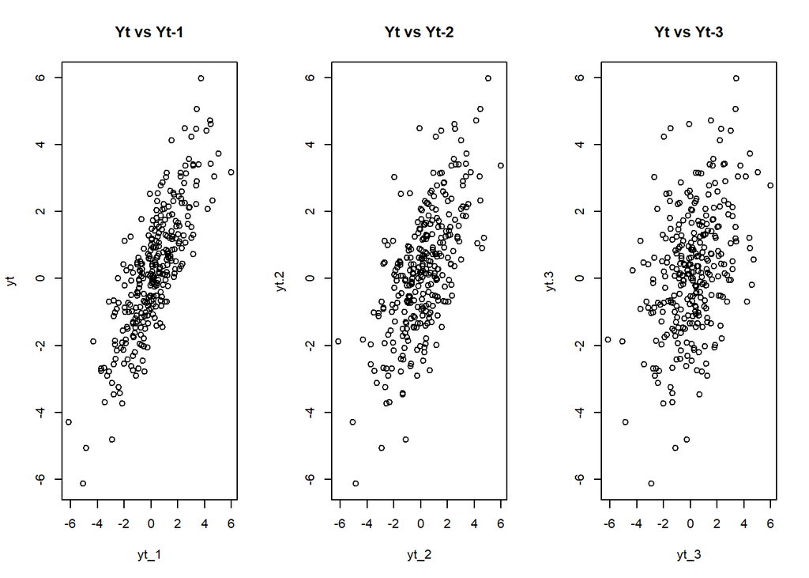

```r
par(mfrow = c(1, 3))
plot(y = yt, x = yt_1, main = "Yt vs Yt-1")
plot(y = yt.2, x = yt_2, main = "Yt vs Yt-2")
plot(y = yt.3, x = yt_3, main = "Yt vs Yt-3")
```

```r
par(mfrow = c(1, 1))
```

Ketiga scatterplot menunjukkan hubungan positif antara Yt dengan Yt-1, Yt-2, dan Yt-3, meskipun kekuatannya semakin menurun seiring bertambahnya lag.

### Autokorelasi Empirik vs Teoritis

```r
cor(yt, yt_1)
```

```
## [1] 0.815228
```

```r
cor(yt.2, yt_2)
```

```
## [1] 0.6523184
```

```r
cor(yt.3, yt_3)
```

```
## [1] 0.39625
```

Karena rumus ACF teoritis ARMA(2,2) cukup kompleks untuk dihitung manual, nilai teoritisnya dihitung menggunakan fungsi `ARMAacf()`:

```r
ARMAacf(ar = c(phi1, phi2), ma = c(theta1, theta2), lag.max = 3)
```

```
##         0         1         2         3
## 1.0000000 0.8591993 0.7491908 0.5464353
```

Nilai korelasi dari data hasil simulasi (baik manual maupun arima.sim) mendekati nilai teoritis di atas, dengan pola autokorelasi yang menurun (*tails off*) seiring bertambahnya lag, sesuai karakteristik proses ARMA.